# Clase 3: Ejercicios

Mara Olvera Carrillo

2026-07-01

```r
library(tidyverse)
library(broom)
```

Trabajamos con los mismos datos de FRED de la clase. Asegúrate de que el archivo `datos/fred_macro.csv` esté en la misma carpeta que este `.Rmd`.

```r
macro <- read_csv("fred_macro.csv") %>%
  mutate(fecha = as.Date(fecha))
```

# Parte 1 — Limpieza y preparación

**Ejercicio 1.** Verifica cuántos `NA` hay en cada columna.

```r
macro %>%
  summarise(across(everything(), ~ sum(is.na(.))))
```

```
## # A tibble: 1 × 4
##   fecha desempleo inflacion tasa_interes
##   <int>     <int>     <int>        <int>
## 1     0         0         0            0
```

```r
macro <- macro %>%
  mutate(
    tasa_lag1 = lag(inflacion, 1),
    desempleo_lag1 = lag(desempleo, 1),
    crisis       = desempleo > 7.5
  )

head(macro, )
```

```
## # A tibble: 6 × 7
##   fecha      desempleo inflacion tasa_interes tasa_lag1 desempleo_lag1 crisis
##   <date>         <dbl>     <dbl>        <dbl>     <dbl>          <dbl> <lgl>
## 1 2000-01-01       4.6      2.57         5.68     NA              NA   FALSE
## 2 2000-02-01       4.5      2.39         5.42      2.57            4.6 FALSE
## 3 2000-03-01       4.6      2.73         5.43      2.39            4.5 FALSE
## 4 2000-04-01       4.7      2.64         5.28      2.73            4.6 FALSE
## 5 2000-05-01       4.5      2.77         5.29      2.64            4.7 FALSE
## 6 2000-06-01       4.5      2.76         5.19      2.77            4.5 FALSE
```

**Ejercicio 3.** Filtra solo las filas del período 2008–2012 y guárdalas en un objeto llamado `crisis_financiera`. ¿Cuántas observaciones tiene?

```r
crisis_financiera <- macro %>% filter(fecha >= as.Date("2008-01-01")& fecha <= as.Date("2012-12-01"))
crisis_financiera
```

```
## # A tibble: 60 × 7
##    fecha      desempleo inflacion tasa_interes tasa_lag1 desempleo_lag1 crisis
##    <date>         <dbl>     <dbl>        <dbl>     <dbl>          <dbl> <lgl>
##  1 2008-01-01       5.3      1.84         1.09      1.9             4.8 FALSE
##  2 2008-02-01       5.5      2.13         1.26      1.84            5.3 FALSE
##  3 2008-03-01       5.8      1.78         1.15      2.13            5.5 FALSE
##  4 2008-04-01       6.1      2.42         1.12      1.78            5.8 FALSE
##  5 2008-05-01       6.3      2.3          1.21      2.42            6.1 FALSE
##  6 2008-06-01       6.9      1.99         1.17      2.3             6.3 FALSE
##  7 2008-07-01       7.3      1.75         1.07      1.99            6.9 FALSE
##  8 2008-08-01       7.7      2.38         1.2       1.75            7.3 TRUE
##  9 2008-09-01       8.2      2.11         0.96      2.38            7.7 TRUE
## 10 2008-10-01       8.6      2.39         1.12      2.11            8.2 TRUE
## # ℹ 50 more rows
```

# Parte 2 — Exploración visual

**Ejercicio 4.** Grafica las tres series (`desempleo`, `inflacion`, `tasa_interes`) en paneles separados usando `facet_wrap`. Los datos deben estar en formato largo antes de graficar.

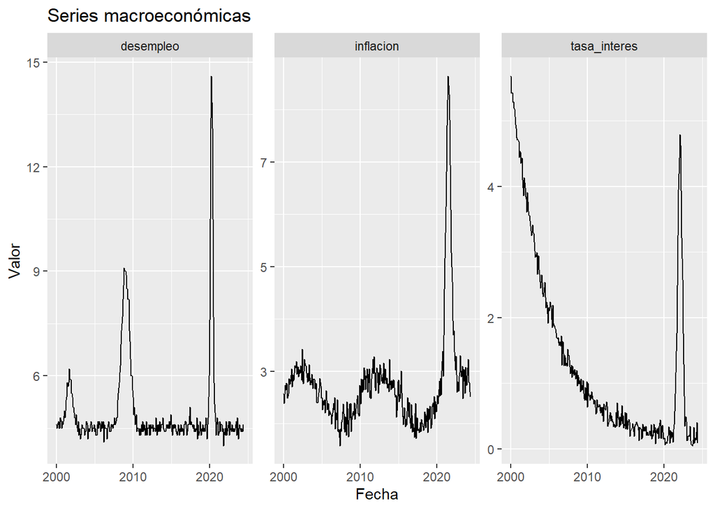

```r
macro %>%
  select(fecha, desempleo, inflacion, tasa_interes) %>%
  pivot_longer(-fecha, names_to = "serie", values_to = "valor") %>%
  ggplot(aes(x = fecha, y = valor)) +
  geom_line() +
  facet_wrap(~ serie, scales = "free_y") +
  labs(
    title = "Series macroeconómicas",
    x = "Fecha",
    y = "Valor"
  )
```

**Ejercicio 5.** Haz un gráfico de dispersión de `desempleo` (eje x) vs `tasa_interes` (eje y). Colorea los puntos por `crisis` y agrega una línea de regresión con `geom_smooth(method = "lm")`.

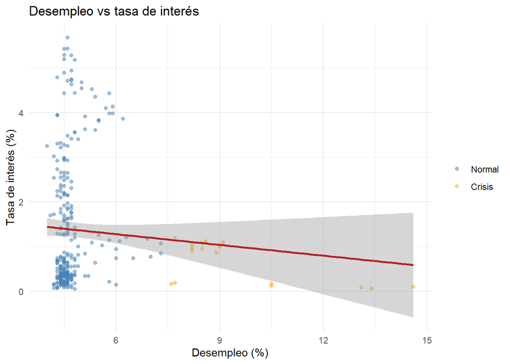

```r
macro %>%
  ggplot(aes(x = desempleo, y = tasa_interes)) +
  geom_point(aes(color = crisis), alpha = 0.5) +
  geom_smooth(method = "lm", se = TRUE, color = "firebrick") +
  scale_color_manual(values = c("FALSE" = "steelblue", "TRUE" = "orange"),
                     labels = c("Normal", "Crisis")) +
  labs(title = "Desempleo vs tasa de interés",
       x = "Desempleo (%)", y = "Tasa de interés (%)",
       color = NULL) +
  theme_minimal()
```

¿Qué relación observas entre desempleo y tasa de interés? ¿Tiene sentido económicamente?

*Tu interpretación aquí.* Primeramente, debemos aclarar que no podríamos decir realmente que es una relación causal por los outliers y el hecho de que se ve en la gráfica la poca capacidad de explicación de la regresión que explica la tasa de interés con la tasa de desempleo. Sin embargo, si encontramos una relación, particularmente en tiempos de crisis. Esto sí tiene sentido económico, ya que cuando el país se enfrenta a tasas altas de desempleo en tiempos de crisis, el banco central reducirá las tasas de interés para intentar estimular la economía y aumentar el empleo.

# Parte 3 — Regresión simple

**Ejercicio 6.** Estima una regresión simple de `tasa_interes` sobre `inflacion`. Guárdala en `modelo_simple`.

```r
modelo_simple <- modelo <- lm(tasa_interes ~ inflacion,
             data = macro)
summary(modelo_simple)
```

```
##
## Call:
## lm(formula = tasa_interes ~ inflacion, data = macro)
##
## Residuals:
##     Min      1Q  Median      3Q     Max
## -2.0050 -0.9716 -0.6673  0.6008  4.3515
##
## Coefficients:
##             Estimate Std. Error t value Pr(>|t|)
## (Intercept)  0.80425    0.24401   3.296   0.0011 **
## inflacion    0.20399    0.08379   2.434   0.0155 *
## ---
## Signif. codes:  0 '***' 0.001 '**' 0.01 '*' 0.05 '.' 0.1 ' ' 1
##
## Residual standard error: 1.409 on 292 degrees of freedom
## Multiple R-squared:  0.01989,    Adjusted R-squared:  0.01654
## F-statistic: 5.927 on 1 and 292 DF,  p-value: 0.01551
```

**Ejercicio 7.** Usa `summary()` para ver los resultados e interpreta: - ¿El coeficiente de `inflacion` es significativo? - ¿Cuánta variación explica el modelo? - ¿El signo del coeficiente tiene sentido económico?

```r
summary(modelo_simple)
```

```
##
## Call:
## lm(formula = tasa_interes ~ inflacion, data = macro)
##
## Residuals:
##     Min      1Q  Median      3Q     Max
## -2.0050 -0.9716 -0.6673  0.6008  4.3515
##
## Coefficients:
##             Estimate Std. Error t value Pr(>|t|)
## (Intercept)  0.80425    0.24401   3.296   0.0011 **
## inflacion    0.20399    0.08379   2.434   0.0155 *
## ---
## Signif. codes:  0 '***' 0.001 '**' 0.01 '*' 0.05 '.' 0.1 ' ' 1
##
## Residual standard error: 1.409 on 292 degrees of freedom
## Multiple R-squared:  0.01989,    Adjusted R-squared:  0.01654
## F-statistic: 5.927 on 1 and 292 DF,  p-value: 0.01551
```

# Parte 4 — Regresión múltiple

**Ejercicio 8.** Estima tres modelos anidados y guárdalos en `m1`, `m2`, `m3`:

- `m1`: `tasa_interes ~ desempleo`
- `m2`: `tasa_interes ~ desempleo + inflacion`
- `m3`: `tasa_interes ~ desempleo + inflacion + tasa_lag1`

```r
m1 <- lm(tasa_interes ~ desempleo,                              data = macro)
m2 <- lm(tasa_interes ~ desempleo + inflacion,                  data = macro)
m3 <- lm(tasa_interes ~ desempleo + inflacion + tasa_lag1, data = macro)
```

**Ejercicio 9.** Compara los tres modelos usando `glance()` y `bind_rows()`. ¿Cuál tiene mejor $R^2$ ajustado? ¿Cuál tiene el AIC más bajo?

```r
list(m1, m2, m3) %>%
  map(glance) %>%
  bind_rows(.id = "modelo") %>%
  select(modelo, r.squared, adj.r.squared, AIC)
```

```
## # A tibble: 3 × 4
##   modelo r.squared adj.r.squared   AIC
##   <chr>      <dbl>         <dbl> <dbl>
## 1 1        0.00586       0.00246 1044.
## 2 2        0.0236        0.0168  1041.
## 3 3        0.0480        0.0381  1023.
```

*Tu interpretación aquí.* El modelo 3 es el que tiene el mejor R ajustado, y también tiene el AIC más bajo. Esta combinación lo haría el mejor modelo de estos 3.

**Ejercicio 10.** Toma tu mejor modelo del ejercicio anterior y usa `tidy()` para ver los coeficientes. Filtra solo los significativos al 5%.

```r
tidy(m3) %>%
  filter(p.value < 0.05)
```

```
## # A tibble: 2 × 5
##   term        estimate std.error statistic p.value
##   <chr>          <dbl>     <dbl>     <dbl>   <dbl>
## 1 (Intercept)    0.954     0.406      2.35 0.0194
## 2 tasa_lag1      0.708     0.265      2.67 0.00794
```

# Parte 5 — Diagnósticos

**Ejercicio 11.** Con `augment()`, haz el gráfico de residuales vs valores ajustados de `m3`. ¿Ves algún patrón problemático?

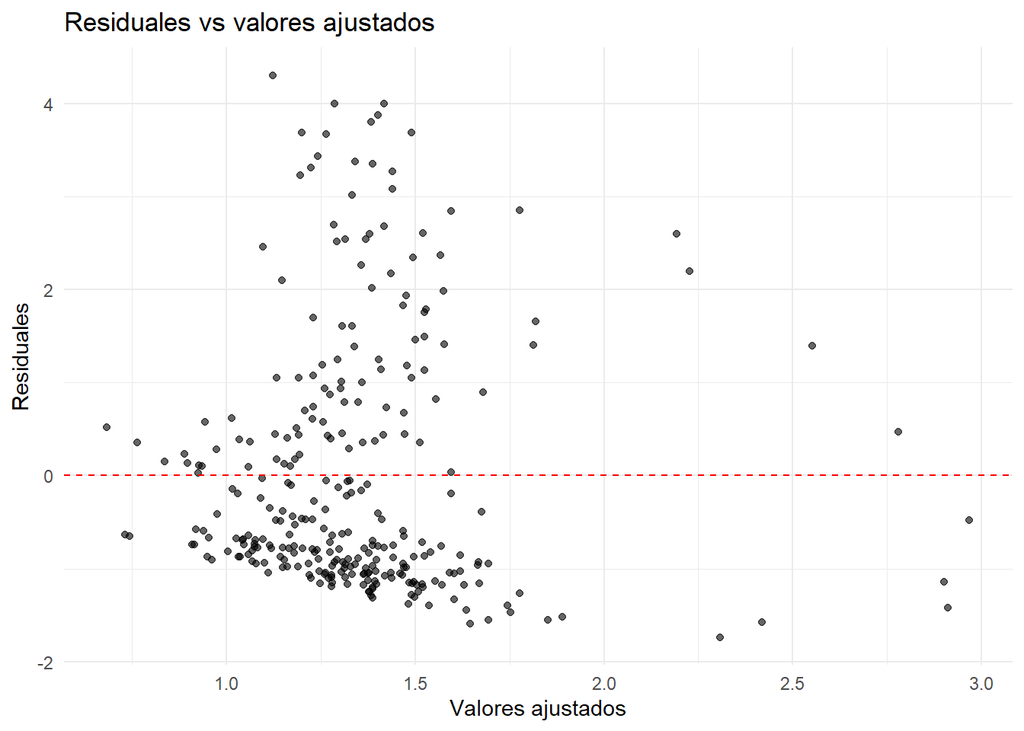

```r
augment(m3) %>%
  ggplot(aes(x = .fitted, y = .resid)) +
  geom_point(alpha = 0.6) +
  geom_hline(yintercept = 0, linetype = "dashed", color = "red") +
  labs(
    title = "Residuales vs valores ajustados",
    x = "Valores ajustados",
    y = "Residuales"
  ) +
  theme_minimal()
```

*Tu interpretación aquí.* En este caso, querríamos que las observaciones tuvieran una distribución que tuviera el 0 en medio, pero aquí vemos que las observaciones se aglomeran mucho más en los negativos.

**Ejercicio 12.** Grafica los residuales de `m3` en el tiempo. Para hacerlo, necesitas agregar la columna `fecha` al resultado de `augment()`. Usa `drop_na()` antes de hacer `augment()` para evitar problemas con los rezagos.

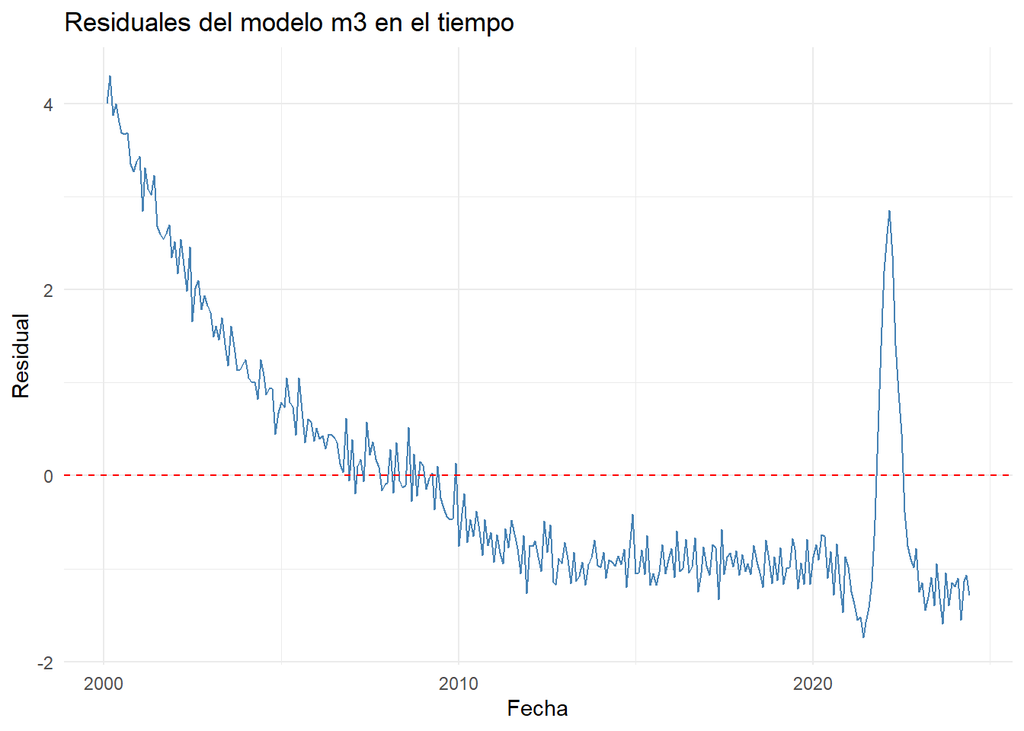

```r
macro_limpio <- macro %>%
  drop_na(tasa_lag1)

m3 <- lm(tasa_interes ~ desempleo + inflacion + tasa_lag1,
  data = macro_limpio)

augment(m3) %>%
  mutate(fecha = macro_limpio$fecha) %>%
  ggplot(aes(x = fecha, y = .resid)) +
  geom_line(color = "steelblue") +
  geom_hline(yintercept = 0, linetype = "dashed", color = "red") +
  labs(
    title = "Residuales del modelo m3 en el tiempo",
    x = "Fecha",
    y = "Residual"
  ) +
  theme_minimal()
```

¿Los residuales muestran algún patrón persistente a lo largo del tiempo?

# Parte 6 — Período de crisis (opcional, para quien termine antes)

**Ejercicio 13.** Estima el mismo modelo `m3` pero usando solo las observaciones del período de crisis financiera (`crisis_financiera` del Ejercicio 3). Compara los coeficientes con los del modelo completo. ¿Cambia la relación durante la crisis?

```r
m3_crisis <- lm(tasa_interes~ desempleo + inflacion + tasa_lag1,
  data = crisis_financiera
)
summary(m3_crisis)
```

```
##
## Call:
## lm(formula = tasa_interes ~ desempleo + inflacion + tasa_lag1,
##     data = crisis_financiera)
##
## Residuals:
##      Min       1Q   Median       3Q      Max
## -0.27726 -0.10611  0.01965  0.08597  0.30789
##
## Coefficients:
##              Estimate Std. Error t value Pr(>|t|)
## (Intercept)  2.008226   0.269619   7.448 6.28e-10 ***
## desempleo    0.007338   0.016835   0.436  0.66463
## inflacion   -0.207266   0.067428  -3.074  0.00326 **
## tasa_lag1   -0.277238   0.065320  -4.244 8.32e-05 ***
## ---
## Signif. codes:  0 '***' 0.001 '**' 0.01 '*' 0.05 '.' 0.1 ' ' 1
##
## Residual standard error: 0.1294 on 56 degrees of freedom
## Multiple R-squared:  0.6898, Adjusted R-squared:  0.6732
## F-statistic: 41.51 on 3 and 56 DF,  p-value: 2.951e-14
```

```r
comparacion <- bind_rows(
  tidy(m3) %>% mutate(modelo = "Completo"),
  tidy(m3_crisis) %>% mutate(modelo = "Crisis")
)

comparacion
```

```
## # A tibble: 8 × 6
##   term        estimate std.error statistic  p.value modelo
##   <chr>          <dbl>     <dbl>     <dbl>    <dbl> <chr>
## 1 (Intercept)  0.954      0.406      2.35  1.94e- 2 Completo
## 2 desempleo   -0.0493     0.0598    -0.824 4.11e- 1 Completo
## 3 inflacion   -0.474      0.264     -1.80  7.37e- 2 Completo
## 4 tasa_lag1    0.708      0.265      2.67  7.94e- 3 Completo
## 5 (Intercept)  2.01       0.270      7.45  6.28e-10 Crisis
## 6 desempleo    0.00734    0.0168     0.436 6.65e- 1 Crisis
## 7 inflacion   -0.207      0.0674    -3.07  3.26e- 3 Crisis
## 8 tasa_lag1   -0.277      0.0653    -4.24  8.32e- 5 Crisis
```